# Anexo — Ejemplo guiado del código de R

Código de la Herramienta 3 · Cálculo de indicadores del Plan Regional de Monitoreo de Especies Prioritarias del PET

Autor/a

Gestión de Datos · MigraMar

Fecha de publicación

27 de octubre de 2026

**Sobre este anexo**

Este anexo muestra cómo se ve el código de R de principio a fin, ejecutado con **datos ficticios**. Cada sección explica en dos líneas qué hace el código y qué debe revisar usted. El código está plegado: haga clic en **Ver código** para abrirlo. Lo único que usted edita (Sección I) está siempre visible.

Los resultados de este ejemplo sirven para aprender a leerlos, no para interpretarlos: no representan ningún monitoreo real.

# Antes de empezar

**Qué hace el código.** Con su archivo de datos crudos, el código calcula el valor anual del indicador, lo evalúa frente a la línea base (AVP) y guarda un archivo .csv listo para Marine Manager de Global Fishing Watch, junto con un reporte en PDF para revisar el resultado antes de publicarlo.

**Qué necesita tener a mano.**

- Su archivo de datos en .csv, con una fila por réplica, filtrado solo para un indicador, una especie y un área (vea la hoja datos_crudos de las Plantillas de datos, Herramienta 2).
- La Referencia metodológica (Herramienta 1), para los parámetros de su indicador.
- El Catálogo de vocabulario (Herramienta 4), para escribir los nombres exactos de especie, indicador y área.

**Cómo está organizado.** Ejecute las secciones en orden. Solo edita la Sección I.

| Sección | Qué hace | ¿Usted edita? |
| --- | --- | --- |
| Preparación | Instala y carga los paquetes de R | No |
| I. Carga y configuración | Carga su archivo y define los parámetros del indicador | **Sí** |
| II. Estandarización | Renombra columnas, divide entre el esfuerzo y limpia filas vacías | No |
| III. Indicador y AVP | Valida la línea base, calcula percentiles y clasifica cada año | No |
| IV. Consolidación | Arma la tabla final con el formato de Marine Manager | No |
| V. Guardar | Guarda el archivo .csv junto a su archivo de datos | No |
| VI. Reporte de revisión | Genera un PDF con lo que se verá en Marine Manager | No |

**Advertencia**

El código no filtra sus datos. Si su archivo mezcla especies, indicadores o áreas, el resultado será incorrecto y el código no podrá detectarlo.

# El ejemplo

Una investigadora de la Universidad XYZ monitorea **tiburón martillo** con cámaras remotas con carnada (BRUVS) pelágicas en la **Isla del Coco**. Su indicador es el **SLE-01**: abundancia relativa en MaxN por hora de grabación. Tiene datos de 2012 a 2025, con una fila por despliegue de cámara.

**Lo que dice la Referencia metodológica para SLE-01**

| Parámetro | Valor |
| --- | --- |
| Estadístico anual | Mediana |
| Interpretación | A |
| Evaluación | AVP |
| Línea base | 5 años |

**Las columnas de su archivo que usa el cálculo**

| Su columna | Corresponde a |
| --- | --- |
| `Year` | Año |
| `S_lewini_MaxN` | Valor medido |
| `Tiempo_video_h` | Esfuerzo |
| `Investigador`, `Institucion`, `Email` | Datos del proveedor |

Sus columnas no necesitan llamarse como en la plantilla, y las que el cálculo no usa (estación, profundidad, observaciones…) pueden quedarse en el archivo.

# Preparación

Instala, si hace falta, y activa los paquetes de R. Ejecútelo siempre.

**Ver código**

```r
# Lista de paquetes requeridos
paquetes <- c("ggplot2", "dplyr", "tidyr", "knitr")

# Identificar cuáles NO están instalados
paquetes_faltantes <- paquetes[!(paquetes %in% installed.packages()[, "Package"])]

# Instalarlos si hace falta
if (length(paquetes_faltantes) > 0) {
  install.packages(paquetes_faltantes)
}

# Cargar todos los paquetes
lapply(paquetes, library, character.only = TRUE)
```

# I. Carga de datos y configuración

## Paso 1 · Cargar su archivo

Se abre una ventana para elegir su archivo .csv. El resultado final se guardará en esa misma carpeta.

**Ver código**

```r
# Al correr este bloque se abrirá una ventana emergente de su explorador de archivos:
# busque su archivo de datos (.csv), selecciónelo y dé clic en "Abrir/Open".
# (Si el código se ejecuta de forma automática para generar un reporte, como en
# este anexo, se usa directamente el archivo de ejemplo indicado abajo.)

if (interactive()) {
  ruta_archivo <- file.choose()
} else {
  ruta_archivo <- "ejemplo_ficticio_SLE-01_cocos_island.csv"
}

cat("Archivo seleccionado:", ruta_archivo, "\n")
cat("Los resultados se guardarán en la carpeta:", normalizePath(dirname(ruta_archivo)), "\n")
```

```
Archivo seleccionado: ejemplo_ficticio_SLE-01_cocos_island.csv
Los resultados se guardarán en la carpeta: /tmp/claude-0/-home-claude/8d45476e-a5b6-5e5b-b058-281fac215ce7/scratchpad/reorg/out/3_aplicacion-calculo
```

A continuación R muestra los nombres de sus columnas y las primeras filas. Copie de aquí los nombres exactos para el Paso 2.

**Ver código**

```r
df_crudo <- read.csv(ruta_archivo, fileEncoding = "Latin1", check.names = FALSE)

cat("\n--> Columnas disponibles en su archivo:\n")
print(colnames(df_crudo))

cat("\n--> Vista previa de las primeras filas:\n")
head(df_crudo)
```

```
--> Columnas disponibles en su archivo:
 [1] "Isla_AMP"       "Fecha_muestreo" "Dia"            "Mes"
 [5] "Year"           "Estacion"       "S_lewini_MaxN"  "Tiempo_video_h"
 [9] "Profundidad_m"  "Investigador"   "Institucion"    "Email"
[13] "Observaciones"

--> Vista previa de las primeras filas:
       Isla_AMP Fecha_muestreo Dia Mes Year Estacion S_lewini_MaxN
1 Isla del Coco     2012-03-04   4   3 2012       E6             5
2 Isla del Coco     2012-03-18  18   3 2012       E2             6
3 Isla del Coco     2012-03-25  25   3 2012       E4            16
4 Isla del Coco     2012-03-29  29   3 2012       E3             0
5 Isla del Coco     2012-03-29  29   3 2012       E1             4
6 Isla del Coco     2012-04-04   4   4 2012       E2             4
  Tiempo_video_h Profundidad_m Investigador     Institucion          Email
1           1.41            27     A. Pérez Universidad XYZ aperez@xyz.org
2           1.52            16     A. Pérez Universidad XYZ aperez@xyz.org
3           1.45            17     A. Pérez Universidad XYZ aperez@xyz.org
4           1.29            23     A. Pérez Universidad XYZ aperez@xyz.org
5           1.03            17     A. Pérez Universidad XYZ aperez@xyz.org
6           1.23            13     A. Pérez Universidad XYZ aperez@xyz.org
     Observaciones
1
2 visibilidad baja
3 visibilidad baja
4 corriente fuerte
5 corriente fuerte
6 visibilidad baja
```

## Paso 2 · Configurar su indicador

Este es el **único bloque que usted modifica**. Reemplace cada valor del ejemplo por el suyo, usando los nombres de columnas del Paso 1, la Referencia metodológica (Parte 2) y el Catálogo de vocabulario.

```r
## =============================================================================
## CAMBIOS MANUALES: Configure las variables de su indicador aquí
## =============================================================================


## AÑO
# Escriba entre comillas el nombre EXACTO de la columna de su archivo que corresponde al año
# En este ejemplo la columna se llama "Year".
# Reemplace lo escrito en el ejemplo por el nombre de su columna.

col_anio            <- "Year"

## VALOR VARIABLE INDICADOR
# Escriba entre comillas el nombre EXACTO de la columna de su archivo que corresponde a la
# variable medida del indicador (p.ej.: "MaxN", "catch_kg"), tal como aparece en la vista
# previa de columnas de la sección anterior — incluyendo espacios si los tuviera (el código ya
# conserva los nombres de columna originales, sin transformarlos).
# En este ejemplo se llama "S_lewini_MaxN".
# Reemplace lo escrito en el ejemplo por el nombre de su columna.

col_valor           <- "S_lewini_MaxN"


## VALOR DE ESFUERZO MUESTREO
# Active la línea de código de col_esfuerzo correspondiente según su caso
# (en este ejemplo: esfuerzo simple, horas de grabación de cada BRUVS):


# INDICADOR YA ESTANDARIZADO:

    # col_esfuerzo <- NULL


# INDICADOR CON ESFUERZO SIMPLE (UNA ÚNICA VARIABLE DE ESFUERZO):

  # Ejemplo: c("horas_buceo")
  # Sustituya el texto entre comillas por el nombre de la columna de su archivo de datos que corresponde a la variable de esfuerzo

    col_esfuerzo <- c("Tiempo_video_h")


# INDICADOR CON ESFUERZO COMPUESTO (CON MÁS DE UNA VARIABLE DE ESFUERZO)

    # - Ejemplo: c("ancho_transecto", "largo_transecto"), Calcula: valor / (ancho × largo)
    # Sustituya el texto entre comillas por el nombre de las columnas de su archivo de datos que corresponden a las variables de esfuerzo


   # col_esfuerzo <- c("ancho_transecto", "largo_transecto")



## METADATOS DEL PROVEEDOR DE DATOS (para darle crédito)
# Se piden en este orden:
#   1) Institución, organización o proyecto propietario del dato, y su página web (si tiene)
#   2) Nombre y correo del punto de contacto
# Para cada dato: si su archivo tiene una columna con ese dato -> Opción A; si no -> Opción B.
# Si no completa ninguna, el campo queda como "No especificado".

# OPCIÓN A: Sustituir el texto entre comillas por el nombre EXACTO de la columna en su archivo (déjelo tal cual si no aplica)
col_institucion     <- "Institucion"    # institución, organización o proyecto propietario del dato
col_dueno_dato      <- "Investigador"   # nombre del punto de contacto
col_contacto        <- "Email"          # correo del punto de contacto

# OPCIÓN B: Sustituir el texto entre comillas por el dato directamente (solo si NO le aplica la Opción A de arriba). Si no hay especificación, déjelo como NA_character_
dato_institucion_directo <- NA_character_     # Ejemplo: "Universidad XYZ"
dato_dueno_directo       <- NA_character_     # Ejemplo: "Juana Pérez" (punto de contacto)
dato_contacto_directo    <- NA_character_     # Ejemplo: "juana.perez@correo.org"

# Página web de la institución, organización o proyecto (opcional). Ejemplo: "www.miproyecto.org"
# Si no aplica, deje NA_character_.
meta_contacto_adicional <- NA_character_



## PARÁMETROS METODOLÓGICOS DEL INDICADOR ##


# Defina los parámetros de su indicador usando la Referencia metodológica (Herramienta 1, Parte 2 — Lista de detalles metodológicos por indicador).


## TIPO ESTADÍSTICO ANUAL
tipo_metrica        <- "mediana"  # Opciones: "mediana", "promedio", "valor_directo"


## TIPO INTERPRETACIÓN
tipo_interpretacion <- "A" # Opciones: "A", "B"


## AÑOS LÍNEA BASE
# Ventana temporal de Línea Base: normalmente 5 años. El código la amplía automáticamente a 10 años más adelante si su línea base no reúne el mínimo de eventos de monitoreo requerido (ver Plan de Monitoreo para más detalle - Capítulo 8, y la Referencia metodológica - Parte 1 para un repaso)

# Sustituya los valores del número de año que corresponda a sus datos
anio_inicio_base    <- 2012
anio_final_base     <- 2016



## METADATOS INDICADOR

# Para completar esta sección, utilice el Catálogo de vocabulario (Herramienta 4) de la siguiente forma
# Nombre especie: Ver Hoja especie_id, columna 'especie_id'
# Nombre indicador: Ver Hoja indicador_id, columna 'id_cmar_gfw'
# Nombre área de estudio: Ver Hoja area_id, columna 'area_id' (si su área no está en el catálogo, asegúrese de comunicar al enlace técnico para definirlo en conjunto)

meta_species        <- "hammerhead_shark"
meta_indicator      <- "relative_abundance_based_on_pelagic_bruvs"
meta_area           <- "cocos_island"


## ESPECIFICACIONES DEL MUESTREO (para el reporte de revisión, Sección VI)
# Describa en pocas palabras dónde y cuándo se tomaron los datos usados en el cálculo.
# Estos textos aparecerán en Marine Manager junto a su indicador.

meta_sitios         <- "los sitios Manuelita, Dirty Rock y Alcyone"   # sitio(s) de muestreo
meta_estacion       <- "la época seca (marzo a mayo)"                  # estación o época de muestreo
meta_unidad         <- "MaxN/hr"                                      # unidad del valor anual


## NOMBRE ARCHIVO RESULTANTE

# El código usará el siguiente nombre para el archivo final que se genera en la Sección V.

# Solo debe cambiar el texto entre comillas por el código-corto de su indicador + el nombre de su área de estudio, tomados del Catálogo de vocabulario (Herramienta 4):
  # código-corto en la hoja 'indicador_id', columna 'codigo_corto';
  # área en la hoja 'area_id', columna 'area_id' (debe coincidir con lo que escribió arriba en 'meta_area').
  # agregar la etiqueta _calculado siempre, por favor.

# El resto del nombre se completa automáticamente: la fecha de hoy (Sys.Date()) y la etiqueta ".csv".

resultado <- paste0("SLE-01_cocos_island_calculado_", Sys.Date(), ".csv")

# Con los valores de este ejemplo, el archivo se llamaría, por ejemplo: "SLE-01_cocos_island_calculado_2026-10-23.csv"

resultado

## =============================================================================
```

```
[1] "SLE-01_cocos_island_calculado_2026-10-27.csv"
```

**Importante**

Desde aquí en adelante no modifique nada: ejecute los bloques en orden y revise los mensajes.

# II. Estandarización de datos

Revisa que el archivo tenga datos, pasa sus columnas a nombres internos, guarda los datos del proveedor, divide el valor entre el esfuerzo, elimina filas sin año o sin valor y cuenta los años con datos.

**Ver código**

```r
# 1. VERIFICAR QUE EL ARCHIVO CARGADO TENGA INFORMACIÓN VÁLIDA
# Confirma que el archivo cargado en la Sección I sí contiene información (que no esté vacío o
# mal leído) antes de continuar con el resto del código.

stopifnot("ERROR: El archivo no contiene datos válidos. Revise que seleccionó el archivo correcto en la Sección I." = nrow(df_crudo) > 0 && ncol(df_crudo) > 0)


# 2. HOMOLOGACIÓN DE NOMBRES DE COLUMNAS
# 2.1. Definir el diccionario (Nombre_Nuevo = Variable_con_Nombre_Viejo)

diccionario_columnas <- c(
  Anio        = col_anio,
  Valor       = col_valor,
  Dueno_Dato  = col_dueno_dato,
  Contacto    = col_contacto,
  Institucion = col_institucion
)

# 2.2 Aplicar renombrado
df_crudo <- df_crudo %>%
  rename(any_of(diccionario_columnas))


# 3. GUARDAR METADATOS DEL PROVEEDOR DE DATOS PARA REFERENCIA POSTERIOR


# Función auxiliar: si la columna existe en el archivo, toma su valor; si no existe, usa el dato escrito directamente en la Sección I (Opción B); si tampoco hay un dato directo, indica "No especificado".

obtener_meta <- function(col, valor_directo, df) {
  if (col %in% colnames(df)) {
    unique(df[[col]])[1]
  } else if (!is.na(valor_directo)) {
    valor_directo
  } else {
    "No especificado"
  }
}

meta_dueno       <- obtener_meta("Dueno_Dato", dato_dueno_directo, df_crudo)
meta_contacto    <- obtener_meta("Contacto", dato_contacto_directo, df_crudo)
meta_institucion <- obtener_meta("Institucion", dato_institucion_directo, df_crudo)

cat("\n  Propietario del dato (institución/organización/proyecto):", meta_institucion, "\n")
cat("  Punto de contacto:", meta_dueno, "\n")
cat("  Correo del punto de contacto:", meta_contacto, "\n")


# 4. ESTANDARIZACIÓN POR ESFUERZO DE MUESTREO

# Esta sección estandariza su variable de monitoreo por el esfuerzo.

if (is.null(col_esfuerzo)) {

  cat("\n✓ Indicador ya estandarizado (sin división por esfuerzo)\n")

} else {

  # Verificar que las columnas de esfuerzo indicadas existan en el archivo
  faltantes_esfuerzo <- setdiff(col_esfuerzo, colnames(df_crudo))
  if (length(faltantes_esfuerzo) > 0) {
    stop("No se encontraron las columnas de esfuerzo: ",
         paste(faltantes_esfuerzo, collapse = ", "))
  }

  if (length(col_esfuerzo) == 1) {
    # Indicador esfuerzo simple: una sola variable de esfuerzo
    df_crudo$Esfuerzo <- df_crudo[[col_esfuerzo]]
    cat("\n✓ Esfuerzo tomado de la columna:", col_esfuerzo, "\n")

  } else if (length(col_esfuerzo) == 2) {
    # Indicador esfuerzo compuesto: esfuerzo = producto de dos variables
    df_crudo$Esfuerzo <- df_crudo[[col_esfuerzo[1]]] * df_crudo[[col_esfuerzo[2]]]
    cat("\n✓ Esfuerzo calculado como", col_esfuerzo[1], "x", col_esfuerzo[2], "\n")

  } else {
    stop("col_esfuerzo debe tener longitud 0 (NULL), 1 o 2, no ", length(col_esfuerzo))
  }

  df_crudo <- df_crudo %>%
    mutate(Valor = Valor / Esfuerzo)
  cat("✓ Indicador estandarizado por esfuerzo\n")
}


# 5. ELIMINAR FILAS VACÍAS O INCOMPLETAS
# Limpiar registros donde falte el año o el valor.

df_crudo <- df_crudo[rowSums(is.na(df_crudo[c("Anio", "Valor")])) == 0, ]


# 6. CONTAR AÑOS PARA LOS QUE HAY DATOS Y VERIFICAR LA COBERTURA TEMPORAL
# Este paso no modifica sus datos: solo calcula cuántos años distintos hay disponibles, para que
# usted confirme que coinciden con su serie.

anios_unicos <- unique(df_crudo$Anio)

anios_totales <- length(anios_unicos)
cat("  Años con datos:", min(anios_unicos), "a", max(anios_unicos),
    "(" , anios_totales, "años totales)\n")
```

```
  Propietario del dato (institución/organización/proyecto): Universidad XYZ
  Punto de contacto: A. Pérez
  Correo del punto de contacto: aperez@xyz.org

✓ Esfuerzo tomado de la columna: Tiempo_video_h
✓ Indicador estandarizado por esfuerzo
  Años con datos: 2012 a 2025 ( 14 años totales)
```

**Revise:** que el proveedor, el contacto y la institución sean correctos, que el esfuerzo venga de la columna esperada y que el rango de años coincida con su serie. En el ejemplo: 14 años (2012–2025).

# III. Indicador y Ámbito de Variación Permisible (AVP)

Para el detalle metodológico, vea el Capítulo 8 del Plan (sección 8.1a).

## A. Validación de la línea base

Comprueba que la línea base tenga al menos 5 años con datos y suficientes eventos de monitoreo. Si no los tiene, la amplía sola a 10 años.

**Ver código**

```r
## SECCIÓN III.A: VALIDAR LÍNEA BASE (con ampliación automática 5 -> 10 años)

# 1. Filtrar datos de la línea base tal como fue definida en la Sección I
df_linea_base <- df_crudo %>%
  filter(Anio >= anio_inicio_base & Anio <= anio_final_base)

if (nrow(df_linea_base) == 0) {
  stop(paste("ERROR: No hay datos en el período de línea base definido:",
             anio_inicio_base, "-", anio_final_base,
             ". Revise los años configurados en la Sección I."))
}

anios_linea_base   <- n_distinct(df_linea_base$Anio)
total_eventos_base <- nrow(df_linea_base)

# 2. Regla 1: menos de 5 años con datos dentro de la línea base -> no se puede calcular el AVP
if (anios_linea_base < 5) {

  stop(paste("ERROR: La línea base tiene datos en solo", anios_linea_base,
             "año(s). Se requieren al menos 5 años para calcular el AVP. Revise su archivo o la ventana de tiempo configurada en la Sección I."))

# 3. Regla 2: hay 5 años pero menos de 15 eventos de monitoreo acumulados -> ampliar a 10 años
} else if (total_eventos_base < 15 && tipo_metrica != "valor_directo") {

  anio_final_original  <- anio_final_base
  anio_final_calculado <- anio_inicio_base + 9
  max_anio_disponible  <- max(df_crudo$Anio)

  # Control de seguridad: verificar si la serie de datos llega hasta ese año
  if (anio_final_calculado > max_anio_disponible) {
    anio_final_base <- max_anio_disponible
    cat("\n⚠️ ADVERTENCIA DE COBERTURA:\n")
    cat("   Se requerían 10 años de línea base por bajo número de eventos, pero la serie",
        "disponible finaliza en", max_anio_disponible, ". Se usará ese límite.\n")
  } else {
    anio_final_base <- anio_final_calculado
  }

  cat("\n⚠️ REAJUSTE AUTOMÁTICO DE LÍNEA BASE:\n")
  cat("   - Período inicial (", anio_inicio_base, "-", anio_final_original, "):",
      total_eventos_base, "eventos acumulados (< 15 requeridos).\n")
  cat("   - Nuevo período ampliado de línea base:", anio_inicio_base, "-", anio_final_base, "\n")

  # Reconstruir la línea base con la nueva ventana ampliada
  df_linea_base      <- df_crudo %>% filter(Anio >= anio_inicio_base & Anio <= anio_final_base)
  anios_linea_base    <- n_distinct(df_linea_base$Anio)
  total_eventos_base  <- nrow(df_linea_base)

} else {
  cat("\n✓ Línea base válida (", anio_inicio_base, "-", anio_final_base, "):",
      total_eventos_base, "eventos acumulados (≥ 15).\n")
}

# 4. Diagnóstico informativo: eventos de monitoreo por año dentro de la línea base final
eventos_por_anio <- df_linea_base %>%
  group_by(Anio) %>%
  summarise(n_eventos = n(), .groups = "drop")

cat("\n--> Eventos de monitoreo por año dentro de la línea base final:\n")
print(eventos_por_anio)

anios_bajos <- eventos_por_anio %>% filter(n_eventos < 10)
if (nrow(anios_bajos) > 0) {
  cat("\n⚠️  Nota: los siguientes años individuales tienen pocos eventos (< 10):\n")
  print(anios_bajos)
  cat("   Esto es solo informativo; no impide el cálculo si el total de la línea base ya es suficiente.\n")
}
```

```
✓ Línea base válida ( 2012 - 2016 ): 55 eventos acumulados (≥ 15).

--> Eventos de monitoreo por año dentro de la línea base final:
# A tibble: 5 × 2
   Anio n_eventos
  <int>     <int>
1  2012        12
2  2013         9
3  2014        11
4  2015        13
5  2016        10

⚠️  Nota: los siguientes años individuales tienen pocos eventos (< 10):
# A tibble: 1 × 2
   Anio n_eventos
  <int>     <int>
1  2013         9
   Esto es solo informativo; no impide el cálculo si el total de la línea base ya es suficiente.
```

**Revise:** el mensaje ✓ confirma que la línea base es válida. En el ejemplo reúne 55 eventos. El aviso ⚠️ sobre 2013 es informativo y no detiene el cálculo.

## B. Estadísticas de la línea base

Resumen descriptivo de los valores de la línea base, solo como referencia.

**Ver código**

```r
## SECCIÓN III.B: PREPARAR DATOS AÑOS LÍNEA BASE

# Extraer todos los valores de monitoreo de la línea base (ya ajustada en III.A si aplicó)
valores_linea_base <- df_linea_base$Valor

# Calcular estadísticas descriptivas del conjunto de datos que componen la línea base, de forma exploratoria.

estadistica_minimo   <- min(valores_linea_base, na.rm = TRUE)
estadistica_maximo   <- max(valores_linea_base, na.rm = TRUE)
estadistica_media    <- mean(valores_linea_base, na.rm = TRUE)
estadistica_mediana  <- median(valores_linea_base, na.rm = TRUE)
estadistica_desvest  <- sd(valores_linea_base, na.rm = TRUE)  # Recomendado para datos continuos
estadistica_varianza <- var(valores_linea_base, na.rm = TRUE)

# Sugerencia: DESVIACIÓN ESTÁNDAR es recomendable para datos continuos o tasas porque expresa la
# variabilidad en las mismas unidades que la media. La varianza es matemáticamente equivalente
# pero en escala cuadrática (menos intuitiva).

tabla_estadisticas <- data.frame(
  Minimo   = round(estadistica_minimo, 4),
  Maximo   = round(estadistica_maximo, 4),
  Media    = round(estadistica_media, 4),
  Mediana  = round(estadistica_mediana, 4),
  Desv_Est = round(estadistica_desvest, 4),
  Varianza = round(estadistica_varianza, 4)
)

cat("\n--> Estadísticas descriptivas de la Línea Base:\n")
print(tabla_estadisticas)
```

```
--> Estadísticas descriptivas de la Línea Base:
  Minimo  Maximo  Media Mediana Desv_Est Varianza
1      0 11.0345 3.4154   3.125   2.4524   6.0144
```

## C. Percentiles del AVP

Calcula P10, P25, P50 y P75 de la línea base: son los umbrales con los que se clasifica cada año.

**Ver código**

```r
## SECCIÓN III.C: CÁLCULO DE PERCENTILES

# Calcular percentiles P10, P25, P50, P75 según metodología del Plan
perc <- quantile(valores_linea_base, probs = c(0.10, 0.25, 0.50, 0.75), na.rm = TRUE)

P10 <- perc[[1]]
P25 <- perc[[2]]
P50 <- perc[[3]]  # Mediana
P75 <- perc[[4]]

cat("\n--> Ámbito de Variación Permisible (AVP) - Percentiles de Línea Base:\n")
cat("  P10 (10%):    ", round(P10, 4), "\n")
cat("  P25 (25%):    ", round(P25, 4), "\n")
cat("  P50 (50%):    ", round(P50, 4), " [Mediana]\n")
cat("  P75 (75%):    ", round(P75, 4), "\n")

# Los valores resultantes arriba corresponden a los umbrales que definirán la categoría de
# su indicador año tras año.
```

```
--> Ámbito de Variación Permisible (AVP) - Percentiles de Línea Base:
  P10 (10%):     0.8279
  P25 (25%):     1.5873
  P50 (50%):     3.125  [Mediana]
  P75 (75%):     4.4918
```

Umbrales del ejemplo

| Valor anual (interpretación A) | Categoría |
| --- | --- |
| ≤ 0.83 (P10) | Crítico |
| 0.83 – 1.59 (P25) | Alerta |
| 1.59 – 3.12 (P50) | Estable |
| 3.12 – 4.49 (P75) | Bueno |
| > 4.49 | Muy bueno |

## D. Valor anual y categoría

Calcula el valor de cada año (aquí, la mediana de sus réplicas) y lo clasifica según los umbrales anteriores.

**Ver código**

```r
## SECCIÓN III.D: CONSTRUCCIÓN DE LA TABLA AVP PARA TODOS LOS AÑOS

# 1. Calcular, para cada año: número de réplicas, mediana, rango intercuartílico (RIC),
#    promedio y desviación estándar (DE). El valor anual del indicador es el estadístico
#    definido en la Sección I (mediana, promedio o valor directo).
indicador_anual <- df_crudo %>%
  group_by(Anio) %>%
  summarise(
    n_eventos = n(),
    Mediana   = median(Valor, na.rm = TRUE),
    RIC       = IQR(Valor, na.rm = TRUE),   # rango intercuartílico: P75 - P25 de las réplicas del año
    Promedio  = mean(Valor, na.rm = TRUE),
    DE        = sd(Valor, na.rm = TRUE),    # queda NA si el año tiene una sola réplica
    Primero   = first(Valor),
    .groups   = "drop"
  ) %>%
  mutate(Valor_Anual = case_when(
    tipo_metrica == "promedio"      ~ Promedio,
    tipo_metrica == "valor_directo" ~ Primero,
    TRUE                            ~ Mediana   # mediana
  ))

# 1b. Medida de dispersión que acompaña al valor anual, según el estadístico anual:
#     mediana -> rango intercuartílico · promedio -> desviación estándar · valor directo -> no aplica (NA).
#     El código de 'dispersion_type' viene del Catálogo de vocabulario (hoja dispersion_id).
if (tipo_metrica == "mediana") {
  indicador_anual$Dispersion <- indicador_anual$RIC
  dispersion_type <- "interquartile_range"
} else if (tipo_metrica == "promedio") {
  indicador_anual$Dispersion <- indicador_anual$DE
  dispersion_type <- "standard_deviation"
} else {
  indicador_anual$Dispersion <- NA_real_
  dispersion_type <- "not_applicable"
}

# 2. Clasificar cada año en una de las 5 categorías AVP, según el tipo de interpretación
if (tipo_interpretacion == "A") {
  indicador_anual <- indicador_anual %>%
    mutate(
      Categoria = case_when(
        Valor_Anual <= P10 ~ "Crítico",
        Valor_Anual <= P25 ~ "Alerta",
        Valor_Anual <= P50 ~ "Estable",
        Valor_Anual <= P75 ~ "Bueno",
        TRUE               ~ "Muy Bueno"
      )
    )
} else {
  indicador_anual <- indicador_anual %>%
    mutate(
      Categoria = case_when(
        Valor_Anual > P75 ~ "Crítico",
        Valor_Anual > P50 ~ "Alerta",
        Valor_Anual > P25 ~ "Estable",
        Valor_Anual > P10 ~ "Bueno",
        TRUE              ~ "Muy Bueno"
      )
    )
}

# Forzar orden jerárquico de categorías (para que el gráfico y la leyenda respeten este orden)
indicador_anual$Categoria <- factor(
  indicador_anual$Categoria,
  levels = c("Crítico", "Alerta", "Estable", "Bueno", "Muy Bueno")
)

# Tabla larga (un renglón por año) - se usa para el gráfico de la sección III.E
tabla_1_AVP <- indicador_anual

cat("\n--> Tabla anual con evaluación AVP:\n")
print(tabla_1_AVP)

# 3. Formato ancho: una columna por año (así lo requiere la plantilla de GFW).
#    Cada celda lleva 3 valores separados por ";": observado;dispersión;predicho.
#    "predicho" queda NA mientras no se use un modelo estadístico. Se redondea a 3 decimales.
f3 <- function(x) ifelse(is.na(x), "NA", sprintf("%.3f", x))
valores_anchos_AVP <- indicador_anual %>%
  mutate(Celda = paste(f3(Valor_Anual), f3(Dispersion), "NA", sep = ";")) %>%
  select(Anio, Celda) %>%
  pivot_wider(names_from = Anio, values_from = Celda)

# 4. Fila única resumen (formato ancho) con percentiles, metadatos y estadísticas descriptivas
tabla_1_AVP_control <- data.frame(
  species        = meta_species,
  indicator      = meta_indicator,
  area           = meta_area,
  metric_type    = "observed_AVP",
  dispersion_type = dispersion_type,
  baseline_years = paste0(anio_inicio_base, "-", anio_final_base),
  P10            = round(P10, 3),
  P25            = round(P25, 3),
  P50            = round(P50, 3),
  P75            = round(P75, 3)
) %>%
  # Une horizontalmente las columnas de todos los años
  bind_cols(valores_anchos_AVP) %>%
  mutate(
    data_owner              = meta_dueno,
    provider_contact        = meta_contacto,
    provider_institution    = meta_institucion,
    additional_contact_info = meta_contacto_adicional
  )


cat("\n--> Fila resumen (AVP, formato ancho) construida con éxito.\n")
```

```
--> Tabla anual con evaluación AVP:
# A tibble: 14 × 10
    Anio n_eventos Mediana   RIC Promedio    DE Primero Valor_Anual Dispersion
   <int>     <int>   <dbl> <dbl>    <dbl> <dbl>   <dbl>       <dbl>      <dbl>
 1  2012        12    3.71 3.44      4.23  2.92   3.55         3.71      3.44
 2  2013         9    3.45 2.76      3.28  2.65   0.847        3.45      2.76
 3  2014        11    2.99 2.22      2.98  1.51   2.99         2.99      2.22
 4  2015        13    1.92 4.50      3.32  3.16   1.90         1.92      4.50
 5  2016        10    3.05 2.50      3.16  1.53   1.59         3.05      2.50
 6  2017        12    2.70 4.77      3.55  2.84   0            2.70      4.77
 7  2018        14    2.65 1.80      2.47  1.58   0            2.65      1.80
 8  2019        11    2.14 2.84      2.76  2.11   0.637        2.14      2.84
 9  2020         8    4.32 2.85      4.37  1.87   4.61         4.32      2.85
10  2021        12    2.58 2.63      3.03  2.32   0            2.58      2.63
11  2022        13    1.03 1.42      1.82  2.77   4.35         1.03      1.42
12  2023        11    1.61 0.997     2.07  1.55   2.42         1.61      0.997
13  2024        12    1.32 3.40      2.00  2.29   5.26         1.32      3.40
14  2025        10    1.70 2.45      1.82  1.83   0            1.70      2.45
# ℹ 1 more variable: Categoria <fct>

--> Fila resumen (AVP, formato ancho) construida con éxito.
```

**Revise:** cada renglón es un año. `n_eventos` es el número de réplicas; `Mediana`, `RIC` (rango intercuartílico), `Promedio` y `DE` (desviación estándar) describen las réplicas del año. `Valor_Anual` es el estadístico elegido (aquí, la mediana), `Dispersion` su medida de dispersión (aquí, el RIC) y `Categoria` la clasificación AVP.

## E. Gráfico de la serie

**Ver código**

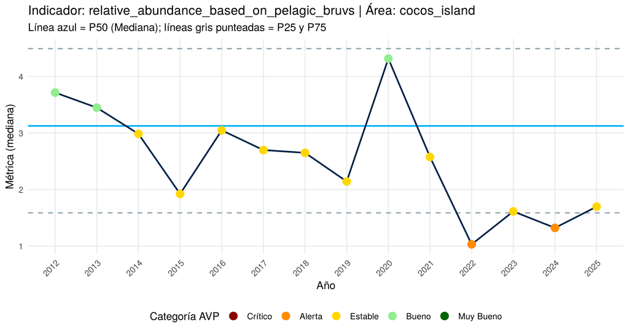

```r
## SECCIÓN III.E: GRÁFICO DE SERIES TEMPORALES

colores_avp <- c(
  "Crítico"   = "#8B0000", # Rojo
  "Alerta"    = "#FF8C00", # Naranja
  "Estable"   = "#FFD700", # Amarillo
  "Bueno"     = "#90EE90", # Verde claro
  "Muy Bueno" = "#006400"  # Verde oscuro
)

grafico_final <- ggplot(tabla_1_AVP, aes(x = Anio, y = Valor_Anual)) +
  geom_hline(yintercept = P50, linetype = "solid", color = "#00B0FF", linewidth = 0.8) +
  geom_hline(yintercept = c(P25, P75), linetype = "dashed", color = "#90A4AE", linewidth = 0.6) +
  geom_line(color = "#002447", linewidth = 0.8) +
  geom_point(aes(color = Categoria), size = 3.5) +
  scale_color_manual(values = colores_avp, drop = FALSE) +
  scale_x_continuous(breaks = min(tabla_1_AVP$Anio):max(tabla_1_AVP$Anio)) +
  theme_minimal() +
  labs(
    title = paste("Indicador:", meta_indicator, "| Área:", meta_area),
    subtitle = "Línea azul = P50 (Mediana); líneas gris punteadas = P25 y P75",
    x = "Año",
    y = paste0("Métrica (", tipo_metrica, ")"),
    color = "Categoría AVP"
  ) +
  theme(
    axis.text.x = element_text(angle = 45, hjust = 1),
    legend.position = "bottom",
    panel.grid.minor = element_blank()
  )

print(grafico_final)
```

Cada punto es un año, coloreado según su categoría. La línea azul es la mediana de la línea base (P50) y las punteadas grises, P25 y P75.

# IV. Consolidación de resultados

Toma la fila de resultados del AVP y ordena sus columnas tal como lo pide la hoja datos_calculados de las Plantillas de datos (Herramienta 2).

**Ver código**

```r
## CONSOLIDACIÓN DE TABLA FINAL PARA PLATAFORMA GFW

cat("\n--> Generando Tabla Consolidada final para GFW...\n")

# Texto "Especificaciones y fuente del dato": se guarda en la columna 'comments' y aparece en
# el reporte de revisión (Sección VI). Usa las especificaciones del muestreo de la Sección I.
texto_dispersion <- switch(tipo_metrica,
  mediana  = "Cada valor anual es la mediana de las réplicas del año, acompañada del rango intercuartílico como medida de dispersión.",
  promedio = "Cada valor anual es el promedio de las réplicas del año, acompañado de la desviación estándar como medida de dispersión.",
  "Cada valor anual es un valor único por año, por lo que no se reporta una medida de dispersión.")

texto_fuente <- paste0(
  "Este indicador se calcula con datos tomados en ", meta_sitios, " (", meta_area, "), durante ",
  meta_estacion, ", entre ", min(indicador_anual$Anio), " y ", max(indicador_anual$Anio), ". ",
  texto_dispersion, " ",
  "Fuente del dato: ", meta_institucion,
  if (!is.na(meta_contacto_adicional)) paste0(" (", meta_contacto_adicional, ")") else "", ". ",
  "Punto de contacto: ", meta_dueno, " (", meta_contacto, ").")

tabla_1_AVP_control$comments <- texto_fuente

# Reordenar las columnas exactamente como lo exige la Plantilla de datos calculados
# (Herramienta 2 / "H2_plantillas-datos.xlsx", hoja "datos_calculados")
tabla_GFW_Final <- tabla_1_AVP_control %>%
  select(
    species, indicator, area, metric_type, dispersion_type, baseline_years,
    P10, P25, P50, P75,
    matches("^[0-9]{4}$"), # Inserta dinámicamente las columnas de años (ej. 2004, 2005...)
    data_owner, provider_contact, provider_institution, additional_contact_info, comments
  )

# Despliegue final en el reporte
cat("\n--> TABLA FINAL CONSOLIDADA PARA GFW:\n\n")
knitr::kable(tabla_GFW_Final, caption = "Tabla Consolidada del Indicador para CMAR / GFW Marine Manager")
```

Así queda la tabla final del ejemplo (presentada en vertical para que se lea mejor; en el archivo .csv es una sola fila):

| Columna | Valor |
| --- | --- |
| species | hammerhead_shark |
| indicator | relative_abundance_based_on_pelagic_bruvs |
| area | cocos_island |
| metric_type | observed_AVP |
| dispersion_type | interquartile_range |
| baseline_years | 2012-2016 |
| P10 | 0.828 |
| P25 | 1.587 |
| P50 | 3.125 |
| P75 | 4.492 |
| 2012 | 3.715;3.443;NA |
| 2013 | 3.448;2.759;NA |
| 2014 | 2.985;2.216;NA |
| 2015 | 1.923;4.499;NA |
| 2016 | 3.048;2.501;NA |
| 2017 | 2.699;4.766;NA |
| 2018 | 2.649;1.804;NA |
| 2019 | 2.143;2.837;NA |
| 2020 | 4.316;2.852;NA |
| 2021 | 2.576;2.631;NA |
| 2022 | 1.031;1.418;NA |
| 2023 | 1.613;0.997;NA |
| 2024 | 1.322;3.399;NA |
| 2025 | 1.697;2.451;NA |
| data_owner | A. Pérez |
| provider_contact | aperez@xyz.org |
| provider_institution | Universidad XYZ |
| additional_contact_info | (vacío) |
| comments | Este indicador se calcula con datos tomados en los sitios Manuelita, Dirty Rock y Alcyone (cocos_island), durante la época seca (marzo a mayo), entre 2012 y 2025. Cada valor anual es la mediana de las… |

La columna `comments` lleva el texto completo de “Especificaciones y fuente del dato” (el mismo del reporte de revisión). Cada columna de año lleva tres valores separados por punto y coma: `observado;dispersión;predicho`, redondeados a 3 decimales. La columna `dispersion_type` indica qué medida de dispersión se usó (aquí, `interquartile_range`). El valor predicho queda `NA` mientras no se use un modelo estadístico. Las estadísticas descriptivas de la Sección III.B no forman parte del archivo.

# V. Guardar el resultado

Guarda el archivo .csv en la misma carpeta de su archivo de datos, con el nombre definido en la Sección I.

**Ver código**

```r
# El archivo se guarda en la misma carpeta donde está su archivo de datos (seleccionado en la Sección I).
ruta_resultado <- file.path(dirname(ruta_archivo), resultado)

# El archivo se guarda en UTF-8 con marca BOM, para que Excel muestre bien las tildes, la ñ y
# otros caracteres especiales (sin esa marca, Excel muestra, por ejemplo, "rÃ©plicas").
# na = "" deja las celdas vacías cuando un campo no aplica (en vez de escribir el texto "NA"),
# tal como se espera en la Plantilla de datos calculados.
con <- file(ruta_resultado, open = "w", encoding = "UTF-8")
writeChar("\ufeff", con, eos = NULL)   # marca BOM
write.csv(tabla_GFW_Final, con, row.names = FALSE, na = "")
close(con)
cat("\n✓ Archivo guardado en:", normalizePath(ruta_resultado), "\n")
```

```
✓ Archivo guardado en: /tmp/claude-0/-home-claude/8d45476e-a5b6-5e5b-b058-281fac215ce7/scratchpad/reorg/out/3_aplicacion-calculo/SLE-01_cocos_island_calculado_2026-10-27.csv
```

# VI. Reporte de revisión previa a publicación

Genera un PDF de 2 páginas. La primera parte muestra **cómo aparecerá su indicador en Marine Manager**: el gráfico y el texto de especificaciones y fuente del dato. Todo lo demás (ficha del indicador, umbrales y estadísticos de la línea base, y valores por año) va en un recuadro gris marcado “Solo para su referencia”: es para que usted revise el cálculo y no se publica. Se guarda junto al archivo .csv. Sirve para revisar el resultado antes de publicarlo, también cuando MigraMar ejecuta el código por usted.

**Ver código**

```r
## SECCIÓN VI: REPORTE DE REVISIÓN PREVIA A PUBLICACIÓN (PDF)
## No requiere cambios: usa lo calculado en las secciones anteriores y las
## especificaciones del muestreo definidas en la Sección I.

library(grid)

# 1. Datos para el reporte (los mismos que van en el archivo final)
codigo_indicador <- sub("_.*$", "", resultado)                  # ej. "SLE-01"
f2 <- function(x, d = 2) formatC(round(x, d), format = "f", digits = d)

datos_rep <- tabla_1_AVP %>% select(Anio, n_eventos, Valor_Anual, Categoria, Mediana, RIC, Promedio, DE)

# 2. Textos que acompañarán al indicador en Marine Manager (en oraciones)
texto_avp <- paste0(
  "La línea base (", anio_inicio_base, "-", anio_final_base, ") define los umbrales del ",
  "Ámbito de Variación Permisible: P10 = ", f2(P10), ", P25 = ", f2(P25),
  ", P50 = ", f2(P50), " y P75 = ", f2(P75), " ", meta_unidad, ".")

# 3. Gráfico como en Marine Manager: línea base sombreada, todos los años con su color AVP
grafico_mm <- ggplot(datos_rep, aes(x = Anio, y = Valor_Anual)) +
  annotate("rect", xmin = anio_inicio_base - 0.5, xmax = anio_final_base + 0.5,
           ymin = -Inf, ymax = Inf, fill = "grey85", alpha = 0.6) +
  annotate("text", x = (anio_inicio_base + anio_final_base) / 2, y = Inf, vjust = 1.5,
           label = "Línea base", size = 3, color = "grey40") +
  geom_line(color = "grey70", linewidth = 0.5) +
  geom_point(aes(color = Categoria), size = 3) +
  scale_color_manual(values = colores_avp, drop = FALSE, name = NULL) +
  scale_x_continuous(breaks = datos_rep$Anio) +
  labs(x = NULL, y = meta_unidad) +
  theme_minimal(base_size = 10) +
  theme(legend.position = "bottom", panel.grid.minor = element_blank(),
        axis.text.x = element_text(angle = 45, hjust = 1))
# 4. Funciones simples para escribir texto en el PDF
y_pos <- 0.95
escribir <- function(txt, tam = 10, negrita = FALSE, color = "#1f2d33", sangria = 0.07,
                     ancho = round(1080 / tam)) {   # caracteres por línea según el tamaño de letra
  lineas <- unlist(lapply(txt, strwrap, width = ancho))
  for (l in lineas) {
    grid.text(l, x = sangria, y = y_pos, just = c("left", "top"),
              gp = gpar(fontsize = tam, fontface = if (negrita) "bold" else "plain", col = color))
    y_pos <<- y_pos - (tam * 1.45) / (11 * 72)
  }
  y_pos <<- y_pos - 0.008
}
titulo <- function(txt) { y_pos <<- y_pos - 0.012; escribir(txt, 12.5, TRUE, "#0b4f6c") }

# 5. Crear el PDF (se guarda junto al archivo .csv)
archivo_reporte <- file.path(dirname(ruta_archivo), sub("\\.csv$", "_reporte-revision.pdf", resultado))
dispositivo <- if (capabilities("cairo")) grDevices::cairo_pdf else grDevices::pdf
dispositivo(archivo_reporte, width = 8.5, height = 11, onefile = TRUE)

# ---- Página 1: así aparecerá en Marine Manager ----
grid.newpage(); y_pos <- 0.95
escribir("Reporte de revisión previa a publicación", 17, TRUE, "#0b4f6c")
escribir(paste0("Indicador ", codigo_indicador, " · ", meta_area, " · Generado el ",
                format(Sys.Date(), "%d/%m/%Y")), 9.5, color = "#4a6572")
escribir("BORRADOR PARA REVISIÓN DEL PROVEEDOR — NO PUBLICADO", 9, TRUE, "#c0392b")
titulo("Así aparecerá su indicador en Marine Manager")
escribir(paste0(meta_species, " · ", meta_indicator), 10, TRUE)
print(grafico_mm, vp = viewport(x = 0.5, y = y_pos, width = 0.88, height = 0.33, just = "top"))
y_pos <- y_pos - 0.345
titulo("Especificaciones y fuente del dato")
escribir(texto_fuente)

# ---- Bloque "Solo para su referencia": ficha -> AVP y estadísticos -> valores por año ----
# Se distingue con un recuadro gris. Si un apartado no cabe, continúa en una página nueva
# dentro del mismo recuadro.
alto_linea <- function(tam) (tam * 1.45) / (11 * 72)
nueva_pagina_referencia <- function(continuacion = TRUE) {
  grid.newpage(); y_pos <<- 0.95
  grid.rect(x = 0.5, y = 0.965, width = 0.90, height = 0.93, just = "top",
            gp = gpar(fill = "#f3f5f6", col = "#c9d1d6"))
  if (continuacion) {
    escribir("Solo para su referencia (continuación) — esta información NO aparecerá en Marine Manager", 11, TRUE, "#4a6572")
  } else {
    escribir("Solo para su referencia — esta información NO aparecerá en Marine Manager", 11, TRUE, "#4a6572")
    escribir("Le compartimos estos resultados para que pueda revisar el cálculo de su indicador.", 9, color = "#4a6572")
  }
}
asegurar_espacio <- function(necesario) if (y_pos - necesario < 0.035) nueva_pagina_referencia()


# 1. Ficha del indicador
ficha <- c(
  paste0("Especie: ", meta_species),
  paste0("Indicador: ", codigo_indicador, " (", meta_indicator, ")"),
  paste0("Área de estudio: ", meta_area),
  paste0("Sitio(s) de muestreo: ", meta_sitios),
  paste0("Estación o época de muestreo: ", meta_estacion),
  paste0("Periodo con datos: ", min(datos_rep$Anio), "-", max(datos_rep$Anio),
         " (", nrow(datos_rep), " años)"),
  paste0("Línea base: ", anio_inicio_base, "-", anio_final_base),
  paste0("Estadístico anual: ", tipo_metrica, " (", meta_unidad, ") · Interpretación: ", tipo_interpretacion),
  paste0("Propietario del dato: ", meta_institucion,
         if (!is.na(meta_contacto_adicional)) paste0(" (", meta_contacto_adicional, ")") else ""),
  paste0("Punto de contacto: ", meta_dueno, " (", meta_contacto, ")"))
# El bloque empieza en la página 1 solo si cabe la ficha completa; si no, empieza en una página nueva
espacio_ficha <- 0.02 + 0.06 + 0.05 + length(ficha) * alto_linea(9.5)
if (y_pos - espacio_ficha < 0.035) {
  nueva_pagina_referencia(continuacion = FALSE)
} else {
  y_pos <- y_pos - 0.02
  grid.rect(x = 0.5, y = y_pos + 0.008, width = 0.90, height = y_pos - 0.03, just = "top",
            gp = gpar(fill = "#f3f5f6", col = "#c9d1d6"))
  escribir("Solo para su referencia — esta información NO aparecerá en Marine Manager", 11, TRUE, "#4a6572")
  escribir("Le compartimos estos resultados para que pueda revisar el cálculo de su indicador.", 9, color = "#4a6572")
}
titulo("Ficha del indicador")
escribir(ficha, 9.5)

# 2. Ámbito de Variación Permisible y estadísticos descriptivos de la línea base (Sección III.B)
asegurar_espacio(0.19)
titulo("Ámbito de Variación Permisible")
escribir(texto_avp)
escribir("Estadísticos descriptivos de la línea base", 10, TRUE)
est <- c(`Réplicas (n)` = as.character(total_eventos_base),
         Mínimo = f2(estadistica_minimo, 3), Máximo = f2(estadistica_maximo, 3),
         Media = f2(estadistica_media, 3), Mediana = f2(estadistica_mediana, 3),
         `Desv. est.` = f2(estadistica_desvest, 3), Varianza = f2(estadistica_varianza, 3))
cols_est <- 0.07 + (seq_along(est) - 1) * 0.125
for (j in seq_along(est)) {
  grid.text(names(est)[j], x = cols_est[j], y = y_pos, just = c("left", "top"),
            gp = gpar(fontsize = 9, fontface = "bold"))
  grid.text(est[[j]], x = cols_est[j], y = y_pos - 0.02, just = c("left", "top"), gp = gpar(fontsize = 9.5))
}
y_pos <- y_pos - 0.055

# 3. Valores por año
asegurar_espacio(0.05 + min(nrow(datos_rep) + 1, 12) * 0.019)
titulo("Valores por año")
cols_x <- c(0.07, 0.14, 0.21, 0.33, 0.48, 0.60, 0.71, 0.83)
encab  <- c("Año", "n", "Valor anual", "Categoría AVP", "Mediana", "RIC", "Promedio", "DE")
alto   <- min(0.019, (y_pos - 0.06) / (nrow(datos_rep) + 1))
for (j in seq_along(encab)) grid.text(encab[j], x = cols_x[j], y = y_pos, just = c("left", "top"),
                                      gp = gpar(fontsize = 9, fontface = "bold"))
for (i in seq_len(nrow(datos_rep))) {
  fila_i <- c(datos_rep$Anio[i], datos_rep$n_eventos[i], f2(datos_rep$Valor_Anual[i], 3),
              as.character(datos_rep$Categoria[i]), f2(datos_rep$Mediana[i], 3), f2(datos_rep$RIC[i], 3),
              f2(datos_rep$Promedio[i], 3), f2(datos_rep$DE[i], 3))
  for (j in seq_along(fila_i)) grid.text(fila_i[j], x = cols_x[j], y = y_pos - i * alto,
                                         just = c("left", "top"), gp = gpar(fontsize = 9))
}
y_pos <- y_pos - (nrow(datos_rep) + 1) * alto - 0.01
grid.text("RIC = rango intercuartílico (P75 - P25 de las réplicas del año) · DE = desviación estándar",
          x = 0.07, y = y_pos, just = c("left", "top"), gp = gpar(fontsize = 8, col = "#4a6572"))

invisible(dev.off())
cat("\n✓ Reporte de revisión guardado en:", normalizePath(archivo_reporte), "\n")
```

```
✓ Reporte de revisión guardado en: /tmp/claude-0/-home-claude/8d45476e-a5b6-5e5b-b058-281fac215ce7/scratchpad/reorg/out/3_aplicacion-calculo/SLE-01_cocos_island_calculado_2026-10-27_reporte-revision.pdf
```

**Siguiente paso**

Si eligió la Ruta B (datos calculados), suba el archivo .csv a su carpeta de recepción, como indica el Manual para proveedores de datos. Si MigraMar calculó el indicador por usted, recibirá este reporte para su revisión antes de que se publique.